# Aside

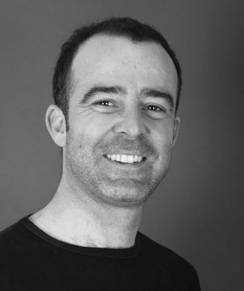

## Contact

- arnaud.milet@d-sidd.com
- [linkedin.com/in/arnaud-milet](https://www.linkedin.com/in/arnaud-milet/)
- https://github.com/arnaudmilet
- +33 6 38 59 74 85

Développement économique et social Emploi / Formation Santé globale des territoires Mesure d’impact

## Compétences

● **Traitement, structuration et analyse de données**: R,Machine learning, Deep learning, Python, SQL  
● **Ingénierie de la donnée**: Jupyter Notebook, versionnage de code (Git, GitHub, GitLab)  
● **Cartographie et interopérabilité des données**: SIG, standards OGC  
● **Datavisualisation, vulgarisation et formation** (formateur R)  
● **Éthique des données, science ouverte**: sensibilisation aux principes d’ouverture de la donnée, habilitation CASD  
● **Recherche documentaire et rédaction de rapports et livrables**

## Disclaimer

Réalisé avec R,2026-08-26.

# Main

## Arnaud Milet

### Data analyst / Statisticien / Economiste

Titulaire d’un master en ingénierie des données en sciences sociales et économie obtenu en 2007, mon parcours s’est construit en bureau d’études spécialisé en urbanisme, en observatoire régional du tourisme, puis en laboratoire universitaire dédié à l’entrepreneuriat avant de créer le bureau d’études D-SIDD en 2016.

Construire des outils d’aide à la décision utiles nécessite un effort de **compréhension du besoin** en cernant les attentes des utilisateurs/décideurs avant la mise en place d’une **chaîne de traitement de la collecte à l’analyse et à la vulgarisation des données**. Je puise dans toutes les ressources disponibles pour apporter un **appui décisif, détaillé et transparent** aux décideurs.

Diagnostic territorial Observatoire Modélisation Datavisualisation & Cartographie Application interactive Tableau de bord & Indicateurs de suivi Open data & open source Collecte et traitement de données Collectivités territoriales & Services de l’État Ethique des données

## Formation

### Master Ingénierie des Données en Sciences Sociales et Economiques

Université de Savoie Mont Blanc

Chambéry

2007

### Certificat de compétences - Création de packages R (2023) - Suivi de version avec git (2025)

ThinkR

Paris

2023  
&  
2025

### DU Data Sciences

Université Paul Valéry

Montpellier

2025  
2026

## Expérience professionnelle

### Data analyst spécialiste des données territoriales

Entrepreneur associé à la CAE Crealead

Montpellier

Depuis 2016

### Data analyst

Mission interministérielle Inserjeunes - beta.gouv:  
Futur Pro, Exposition des données InserJeunes & InserSup

Distanciel, 3/5

2023  
2026

### Ingénieur d’études

Labex Entreprendre

Montpellier

2013  
2014

### Consultant statisticien

Indépendant

Nouméa

2012

### Chargé d’études statistiques

CRT Bretagne

Rennes

2010  
2011

### Chargé d’études statistiques

AID observatoire

Lyon

2008  
2010

Références

Développement économique et social

- Baromètre appui à la coopération des GAL LEADER (ACGL), Réseau Rural Français, 2026.

- Impact socio-économique des CAE en France, Confédération générale des SCOP, 2025.

- Étude sur la mise en cohérence des fonctionnements du Services Intégré d’Accueil et d’Orientation (SIAO) avec les exigences du Logement d’Abord, SIAO 13, 2023.

- Indicateurs de suivi socio-économique stratégique, Région Sud, 2022.

- Elaboration d’outils nationaux liés à la gouvernance et à la mise en œuvre des fonds européens, ANCT – Région Sud, 2022.

- Automatisation du baromètre de la coopération LEADER, Réseau Rural Français, 2021.

- Diagnostic des flux et des interactions interterritoriales, ANCT - PETR Centre-Ouest Aveyron, 2021.

- Analyse des déterminants du choix de résidence des ménages, Loire Forez agglomération, 2019.

- Diagnostic de l’offre d’accompagnement de l’ESS, Région Occitanie, 2018.

- Analyse du risque agricole pour l’IFAD Platform for Agricultural Risk Management, PARM, 2016.

- Analyse des flux de consommation des ménages sur plusieurs dizaines de territoires, Multiple, 2008 à 2010.

Références d-sidd

Mesure d’impact & modélisation

- Evaluation des parcours des participants du Fonds social européen (FSE et FSE+), DGEFP, 2026.

- Evaluation Plan Stratégiques National (PSN) de la Politique Agricole Commune (PAC) 2023-2027, Ministère de l’Agriculture et de la Souveraineté Alimentaire, 2026.

- Impact socio-économique des CAE en France, Confédération générale des SCOP, 2025.

- Etude socioéconomique de la pêche de loisir et de son potentiel de développement en Région Grand Est, ARGE, 2024.

- Modélisation et conseil pour la mise en place de vérifications de gestion ciblées sur les risques dans le cadre du pilotage des fonds européens, Région Bourgogne-Franche-Comte, 2024.

- Etude d’impact du projet PISCOFAM, Ministère de la Pêche et de l’Economie Maritime de Guinée - AFD, 2023.

- Collecte et traitement des données sur la collecte, le traitement et la valorisation des déchets marins sur le littoral atlantique, Clean Atlantic, Union Européenne, 2022.

- Prévision des effectifs scolaires, Mairie de Prades-le-Lez, 2022.

- Cartographie des activités de valorisation non académique des chercheurs, CNRS, 2021.

- Analyse de la chaîne d’approvisionnement de la restauration collective et réalisation d’une application interactive collaborative, Région Centre-Val-de-Loire, 2016.

- Tourisme durable : Impact économique, environnemental et social du tourisme sur les destinations bretonnes, CRT Bretagne, 2011.

Références d-sidd

Santé globale des territoires

- Structuration des données de suivi du Plan de Protection de l’Atmosphère de la zone urbaine de Nîmes, DREAL Occitanie, 2023.

- Observatoire sur la perception de la nuisance liée aux moustiques, EID Méditerranée, 2021.

- Diagnostic des déserts médicaux et modélisation de l’offre de téléconsultation, E-Meuse santé, 2020 – 2023.

- Baromètre des activités de pleine nature, Département des Alpes-Maritimes, 2020.

- Réalisation d’une application de mesure du potentiel de télétravail en France, Relais d’Entreprises, 2018.

- Diagnostic de la santé, la qualité de vie et du bien-être, Grand Narbonne, 2017.

- Observatoire de la qualité de vie, Région Auvergne-Rhône-Alpes, 2017.

- Mesure du potentiel de consommation en circuits courts, CC du Grand Pic Saint Loup, 2017.

- Applications interactives et libres de diagnostic d’accessibilité aux circuits-courts, aux tiers-lieux et végétalisation de l’espace urbain, D-SIDD, 2016.

Références d-sidd

Emploi/ Formation

- Impact socio-économique des CAE en France, Confédération générale des SCOP, 2025.

- Data Analyst pour la mission InserJeunes de beta.gouv, beta gouv, 2023-2026.

- Optimisation d’un outil de projections macro-économiques par métier à moyen terme, Cap Métiers – Nouvelle-Aquitaine, 2022-2023.

- How do research-based start-ups overcome the Valley of Death?. Bessiere, Veronique & Gomez Breysse, Marie & Messeghem, Karim & Milet, Arnaud & Sammut, Sylvie., Labex entreprendre, 2014.

Références d-sidd

Formations

- Formations au logiciel R: Initiation; Construire un package; Analyses statistiques; Gestion de base de données; Datavisualisation; Géomatique/cartographie; Programmation, INRAE, CIRAD, INSERM, CNRS, IFREMER, Département du Bas-Rhin, Cap Métiers, EMFOR, 2016-2024.

Références d-sidd